# Reproducible Research: Peer Assessment 1

Luiz Carlos Moutinho Pataca

December 14, 2016

## Loading and preprocessing the data

```r
#Loading compressed file "activity.zip" with read.csv() function, and defining
#class for each variable.
activity <- read.csv(file = unzip(zipfile = "activity.zip", files = "activity.csv"),
                     header = TRUE, na.strings = "NA",
                     colClasses = c("integer", "Date", "integer"))
```

## What is mean total number of steps taken per day?

```r
# Calculating total number of steps taken per day. Missing values are ignored.
total_day <- aggregate(activity$steps, by = list(activity$date), sum)
names(total_day) <- c("date", "steps")
```

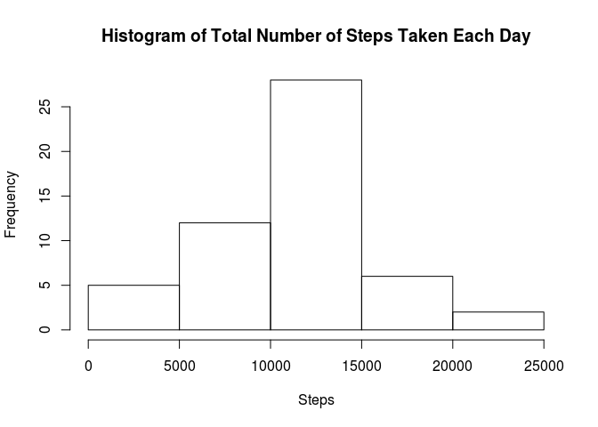

```r
# Creating a histogram of total number of steps taken each day.
hist(total_day$steps,
     main = "Histogram of Total Number of Steps Taken Each Day",
     xlab = "Steps")
```

```r
# Calculating and reporting the mean and median of the total number of steps
# taken per day.
Mean <- mean(total_day$steps, na.rm = TRUE)
Median <- median(total_day$steps, na.rm = TRUE)

library(knitr)
kable(cbind(Mean, Median),
      caption = "Mean and Median of the total number of steps taken per day",
      align = c("l", "l"))
```

Mean and Median of the total number of steps taken per day

| Mean | Median |
| --- | --- |
| 10766.19 | 10765 |

## What is the average daily activity pattern?

Using function aggregate() for calculating 5-minute interval mean across all days.

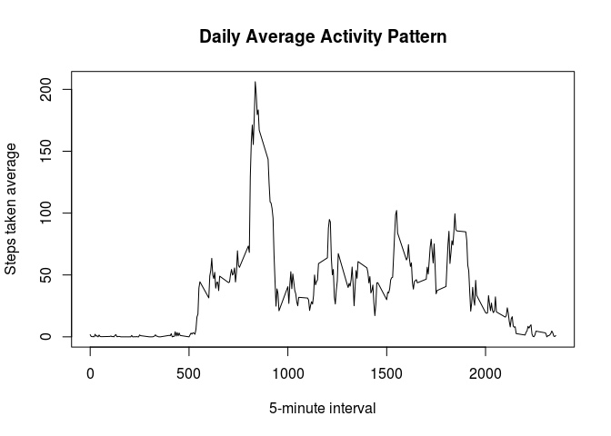

```r
daily_mean <- aggregate(x = activity$steps, by = list(activity$interval),
                        FUN = "mean", na.rm = TRUE)
names(daily_mean) <- c("interval", "steps")

# Ploting daily average
plot(x = daily_mean$interval, y = daily_mean$steps, type = "l",
     xlab = "5-minute interval", ylab = "Steps taken average",
     main = "Daily Average Activity Pattern")
```

Determining the 5-minute interval with the largest number of steps.

```r
id_max <- which.max(daily_mean$steps)
Interval_max <- daily_mean$interval[id_max]
```

*5-minute Interval with maximum number of steps: 835*

## Imputing missing values

Calculating and reporting the total number of missing values in the dataset.

```r
missing_values <- sum(is.na(activity$steps))
```

*Total missing values in the dataset: 2304*

Using 5-minute interval total average for filling missing values in the dataset.

```r
activity_fill <- merge(x = activity, y = daily_mean, by="interval", suffixes=c("",".mean"))
id_na <- is.na(activity_fill$steps)
activity_fill$steps[id_na] <- activity_fill$steps.mean[id_na]
activity_fill <- activity_fill[order(activity_fill$date, activity_fill$interval), c(2, 3, 1)]
activity_fill$steps <- as.integer(round(x = activity_fill$steps, digits = 0))
```

**Properties and Summary of original dataset**

```r
str(activity)
```

```
## 'data.frame':    17568 obs. of  3 variables:
##  $ steps   : int  NA NA NA NA NA NA NA NA NA NA ...
##  $ date    : Date, format: "2012-10-01" "2012-10-01" ...
##  $ interval: int  0 5 10 15 20 25 30 35 40 45 ...
```

```r
summary(activity)
```

```
##      steps             date               interval
##  Min.   :  0.00   Min.   :2012-10-01   Min.   :   0.0
##  1st Qu.:  0.00   1st Qu.:2012-10-16   1st Qu.: 588.8
##  Median :  0.00   Median :2012-10-31   Median :1177.5
##  Mean   : 37.38   Mean   :2012-10-31   Mean   :1177.5
##  3rd Qu.: 12.00   3rd Qu.:2012-11-15   3rd Qu.:1766.2
##  Max.   :806.00   Max.   :2012-11-30   Max.   :2355.0
##  NA's   :2304
```

**Properties and Summary of dataset with filled missing values**

```r
str(activity_fill)
```

```
## 'data.frame':    17568 obs. of  3 variables:
##  $ steps   : int  2 0 0 0 0 2 1 1 0 1 ...
##  $ date    : Date, format: "2012-10-01" "2012-10-01" ...
##  $ interval: int  0 5 10 15 20 25 30 35 40 45 ...
```

```r
summary(activity_fill)
```

```
##      steps             date               interval
##  Min.   :  0.00   Min.   :2012-10-01   Min.   :   0.0
##  1st Qu.:  0.00   1st Qu.:2012-10-16   1st Qu.: 588.8
##  Median :  0.00   Median :2012-10-31   Median :1177.5
##  Mean   : 37.38   Mean   :2012-10-31   Mean   :1177.5
##  3rd Qu.: 27.00   3rd Qu.:2012-11-15   3rd Qu.:1766.2
##  Max.   :806.00   Max.   :2012-11-30   Max.   :2355.0
```

Calculating total number of steps taken per day. Missing values are filled in.

```r
total_day_fill <- aggregate(activity_fill$steps, by = list(activity_fill$date), sum)
names(total_day_fill) <- c("date", "steps")
```

Creating a histogram of total number of steps taken each day. Missing values are filled in.

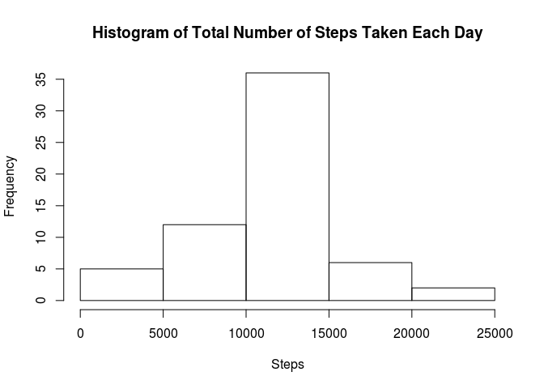

```r
hist(total_day_fill$steps,
     main = "Histogram of Total Number of Steps Taken Each Day",
     xlab = "Steps")
```

Calculating and reporting the mean and median of the total number of steps taken per day. Missing values are filled in.

```r
Mean <- mean(total_day_fill$steps, na.rm = TRUE)
Median <- median(total_day_fill$steps, na.rm = TRUE)

library(knitr)
kable(cbind(Mean, Median),
      caption = "Mean and Median of the total number of steps taken per day. Missing values are filled in.",
      align = c("l", "l"))
```

Mean and Median of the total number of steps taken per day. Missing values are filled in.

| Mean | Median |
| --- | --- |
| 10765.64 | 10762 |

The histogram and calculated values of Mean and Median show that the impact of imputing missing data on the estimates of the total daily number of steps is rather low.

## Are there differences in activity patterns between weekdays and weekends?

```r
# First defining english locale
Sys.setlocale(category = "LC_ALL", locale = "en_US.UTF-8")
```

```
## [1] "LC_CTYPE=en_US.UTF-8;LC_NUMERIC=C;LC_TIME=en_US.UTF-8;LC_COLLATE=en_US.UTF-8;LC_MONETARY=en_US.UTF-8;LC_MESSAGES=pt_BR.UTF-8;LC_PAPER=pt_BR.UTF-8;LC_NAME=C;LC_ADDRESS=C;LC_TELEPHONE=C;LC_MEASUREMENT=pt_BR.UTF-8;LC_IDENTIFICATION=C"
```

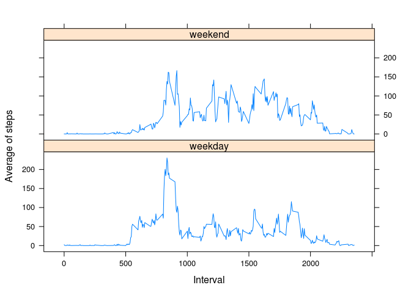

```r
# Creating a new factor variable indicating whether a given date is a weekday or
# weekend day
weekday <- weekdays(activity_fill$date)
id_weekend <- which(weekday == "Saturday" | weekday == "Sunday")
weekday[id_weekend] <- "weekend"
weekday[-id_weekend] <- "weekday"
activity_fill$weekday <- as.factor(weekday)
# Calculating total average of number of steps for weekdays and weekends
total_weekday <- aggregate(steps ~ interval + weekday, data = activity_fill, mean)
# Plotting
library("lattice")
xyplot(steps ~ interval | weekday, total_weekday, type = "l", layout = c(1, 2),
    xlab = "Interval", ylab = "Average of steps")
```

The plots show differences between weekdays and weekends. On weekdays more steps are taken before 10:00 am compared to weekends.